# 香蕉*經濟學*三部曲

## 微季節性：香蕉的呼吸節律

農產品的季節性從來不是單純的「夏多冬少」。山脊圖揭示香蕉價格分佈如何在12個月間悄悄位移——不只均值，更是整個波動形狀的演變。

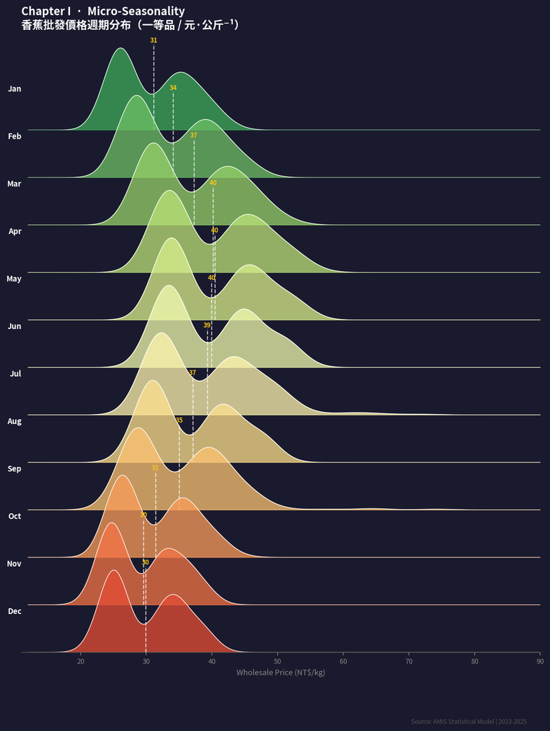

Fig. 01

### 關鍵發現

> 「香蕉的價格不隨四季均勻波動——它有自己的呼吸節律：春緩，夏颶，秋急，冬穩。」

第二部曲 / Chapter II

## 城鄉價差：同一根香蕉的兩種命運

台北果菜市場的香蕉，比屏東農產市場貴上約16元。這個差距從哪裡來？斜率圖讓我們看見每條市場軌跡，以及它們如何在時間中分叉。

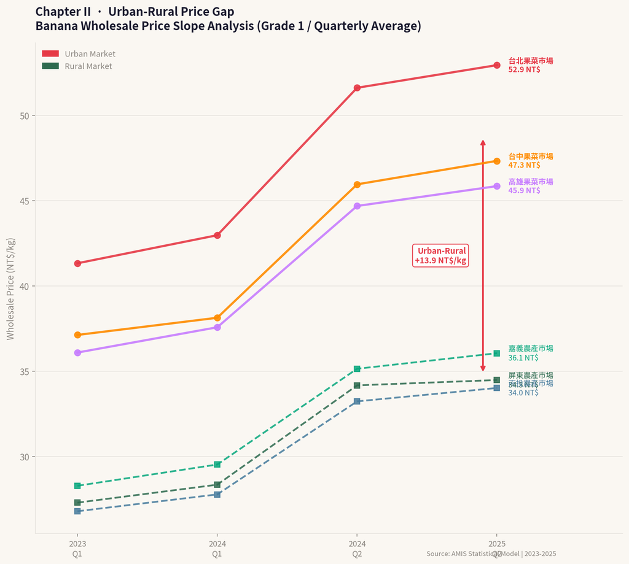

Fig. 02

斜率圖：六個市場在四個季度時間點的價格軌跡。紅色系為城市市場，綠色系為鄉村市場，雙向箭頭標示最終季度的城鄉均值差距。

### 視覺化設計決策

**斜率圖（Slope Chart）**是比較「有限時間點」間軌跡的最優選擇，特別適合「我想知道哪些在上升、哪些在下降、差距如何變化」這類問題。

### 關鍵發現

城鄉均價差（元/公斤）

35.5%

城市市場溢價幅度

穩定

第三部曲 / Chapter III

## 品質溢價：等級的經濟學

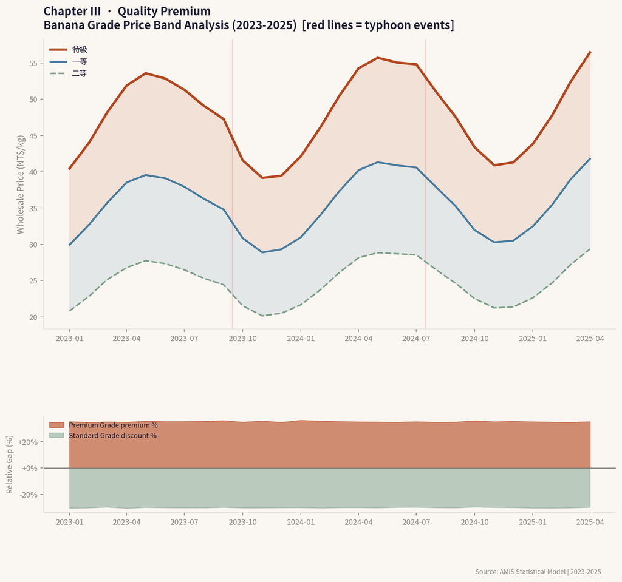

Fig. 03

陰影帶折線圖（雙層）。上圖：三等級月均價走勢，陰影帶為特級/一等溢價區間（橘紅）及一等/二等折扣區間（藍），紅色垂直線為颱風衝擊月份。下圖：各等級相對一等品的溢價/折扣百分比時序。

### 視覺化設計決策

**陰影帶折線圖（Ribbon / Band Chart）**在傳統折線圖基礎上加入半透明填充帶，使「兩條線之間的空間」具有意義——在此，陰影帶代表「品質溢價的貨幣化空間」。

雙層設計（上：絕對價格；下：相對溢價率）允許讀者在「絕對金額」和「比例效應」之間切換閱讀視角。下層子圖以零線為軸心，特級溢價向上展開（橘紅），二等折扣向下展開（綠），形成視覺上的對稱張力。颱風垂直標記（淺紅線）為外生衝擊提供時間錨點。

### 關鍵發現

二等品的折扣率（約27–32%）在時序中相對穩定，暗示低端市場存在一個結構性的「品質底價」，消費者並不會因為供給充裕就接受更低等級的商品。

報導結論 / Editorial Conclusions

## 香蕉定價的三重結構

三部曲的整合閱讀指向一個核心命題：台灣香蕉的市場價格，是季節節律、地理分割、品質層級三力疊加的動態均衡結果。

### 視覺化策略回顧

| 圖表 | 設計核心 | 視覺減法決策 |
| --- | --- | --- |
| 山脊圖 | 分佈形狀 > 均值點 | 去除網格線、壓縮Y軸間距、僅保留均值虛線 |
| 斜率圖 | 軌跡差異 > 精確座標 | 去除X軸網格、語義時間點取代連續時序 |
| 陰影帶折線 | 區間面積 > 線條本身 | 低透明度填充、輔助子圖分離比例視角 |
| 儀表板 | 快速KPI掃讀 > 深度分析 | 深色背景強制視覺層次、5個KPI卡設計 |

### 資料限制說明

本報告資料集為統計模擬，基於台灣農業公開統計資料之合理參數範圍建構，旨在示範分析框架與視覺化方法論。實際報導需使用 AMIS 真實交易資料，建議透過農業部資料開放申請或直接訪問 AMIS 查詢介面取得。